# microbiome

wentao

2021/5/3

## Introducrion

The microbiome R package facilitates exploration and analysis of microbiome profiling data, in particular 16S taxonomic profiling.

### 导入数据

```r
library(microbiome)
library(phyloseq)
library(gcookbook)
library(tidyverse)

library(ggClusterNet)
data(ps)

theme_set(theme_bw(21))
```

### 微生物组数据基本统计描述

```r
summarize_phyloseq(ps)
```

```
## [[1]]
## [1] "1] Min. number of reads = 32049"
##
## [[2]]
## [1] "2] Max. number of reads = 38951"
##
## [[3]]
## [1] "3] Total number of reads = 644840"
##
## [[4]]
## [1] "4] Average number of reads = 35824.4444444444"
##
## [[5]]
## [1] "5] Median number of reads = 36745.5"
##
## [[6]]
## [1] "7] Sparsity = 0.193483242067653"
##
## [[7]]
## [1] "6] Any OTU sum to 1 or less? NO"
##
## [[8]]
## [1] "8] Number of singletons = 0"
##
## [[9]]
## [1] "9] Percent of OTUs that are singletons \n        (i.e. exactly one read detected across all samples)0"
##
## [[10]]
## [1] "10] Number of sample variables are: 10"
##
## [[11]]
##  [1] "Group"                "Date"                 "Site"
##  [4] "Sequencing"           "Platform"             "Species"
##  [7] "Batch"                "BarcodeSequence"      "LinkerPrimerSequence"
## [10] "ReversePrimer"
```

### alpha多样性

microbiome极大的扩展了alpha多样性的内容

```r
tab <- alpha(ps, index = "all")
head(tab)
```

```
##     observed    chao1 diversity_inverse_simpson diversity_gini_simpson
## KO1     2342 2670.889                 102.73444              0.9902662
## KO2     2348 2669.335                 122.27022              0.9918214
## KO3     2014 2335.322                  94.86513              0.9894587
## KO4     2071 2399.030                  94.90735              0.9894634
## KO5     1885 2231.126                  69.27647              0.9855651
## KO6     2205 2487.501                 122.47241              0.9918349
##     diversity_shannon diversity_fisher diversity_coverage evenness_camargo
## KO1          6.123919         574.8122                 69        0.2235762
## KO2          6.165290         561.8219                 71        0.2220993
## KO3          5.822542         450.4207                 48        0.1869791
## KO4          5.828110         469.8255                 47        0.1859324
## KO5          5.547834         413.8141                 37        0.1683774
## KO6          6.042550         514.1677                 60        0.2048702
##     evenness_pielou evenness_simpson evenness_evar evenness_bulla dominance_dbp
## KO1       0.7892909       0.04386611     0.3697614      0.3855023    0.05783582
## KO2       0.7943611       0.05207420     0.3547765      0.3827500    0.05446243
## KO3       0.7653307       0.04710285     0.3177658      0.3432999    0.06046058
## KO4       0.7632626       0.04582682     0.3245914      0.3401828    0.05820606
## KO5       0.7356228       0.03675144     0.3029330      0.3081601    0.07406932
## KO6       0.7849014       0.05554304     0.3407832      0.3619913    0.04917988
##     dominance_dmn dominance_absolute dominance_relative dominance_simpson
## KO1    0.10095691               1922         0.05783582       0.009733834
## KO2    0.08841843               1968         0.05446243       0.008178606
## KO3    0.09209006               2355         0.06046058       0.010541281
## KO4    0.09421089               2218         0.05820606       0.010536592
## KO5    0.11193838               2885         0.07406932       0.014434915
## KO6    0.07860120               1817         0.04917988       0.008165104
##     dominance_core_abundance dominance_gini rarity_log_modulo_skewness
## KO1                0.4801998      0.8077347                   2.060773
## KO2                0.4706240      0.8102152                   2.060449
## KO3                0.5250700      0.8626805                   2.060119
## KO4                0.4964310      0.8599368                   2.060031
## KO5                0.5493967      0.8897958                   2.060103
## KO6                0.4743680      0.8346200                   2.060413
##     rarity_low_abundance rarity_rare_abundance
## KO1            0.4691562             0.4430368
## KO2            0.4693234             0.4574789
## KO3            0.3918770             0.3984237
## KO4            0.3893875             0.4262583
## KO5            0.3275738             0.3555841
## KO6            0.4341471             0.4215883
```

### beta多样性排序

https://microbiome.github.io/tutorials/Ordination.html

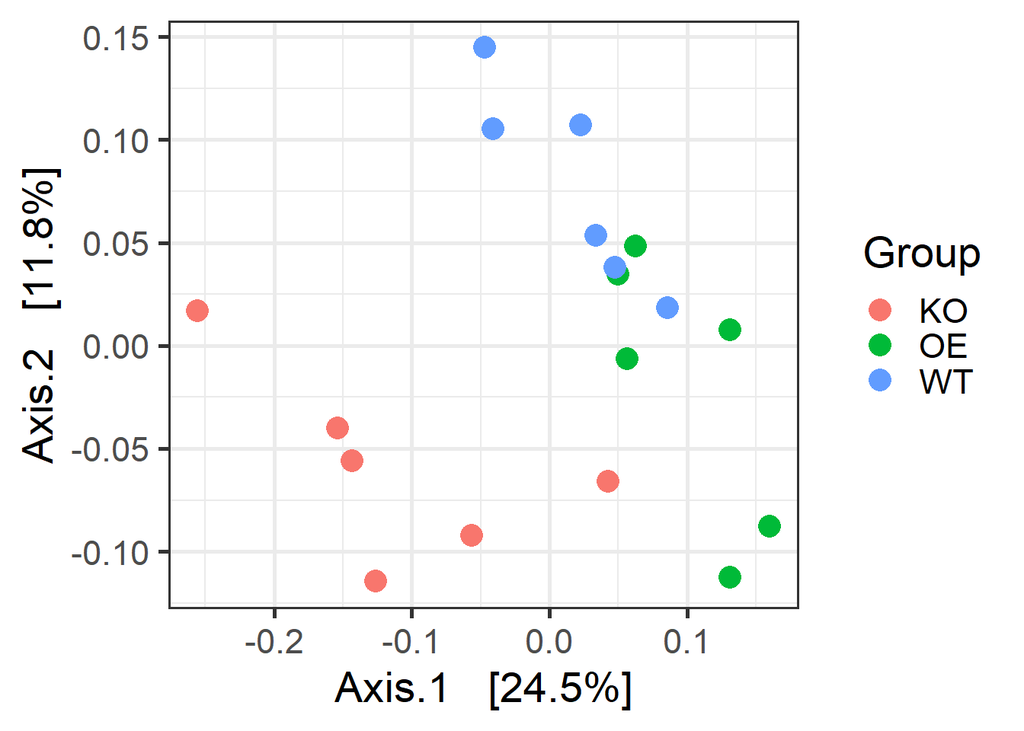

```r
# Convert to compositional data
pseq <- pseq.rel <- microbiome::transform(ps, "compositional")

# Pick core taxa with with the given prevalence and detection limits
pseq.core <- core(pseq.rel, detection = .1/100, prevalence = 90/100)
# Use relative abundances for the core
pseq.core <- microbiome::transform(pseq.core, "compositional")
# Ordinate the data
set.seed(4235421)
# proj <- get_ordination(pseq, "MDS", "bray")
ord <- ordinate(pseq, "MDS", "bray")
plot_ordination(pseq, ord, color = "Group") +
                geom_point(size = 5)
```

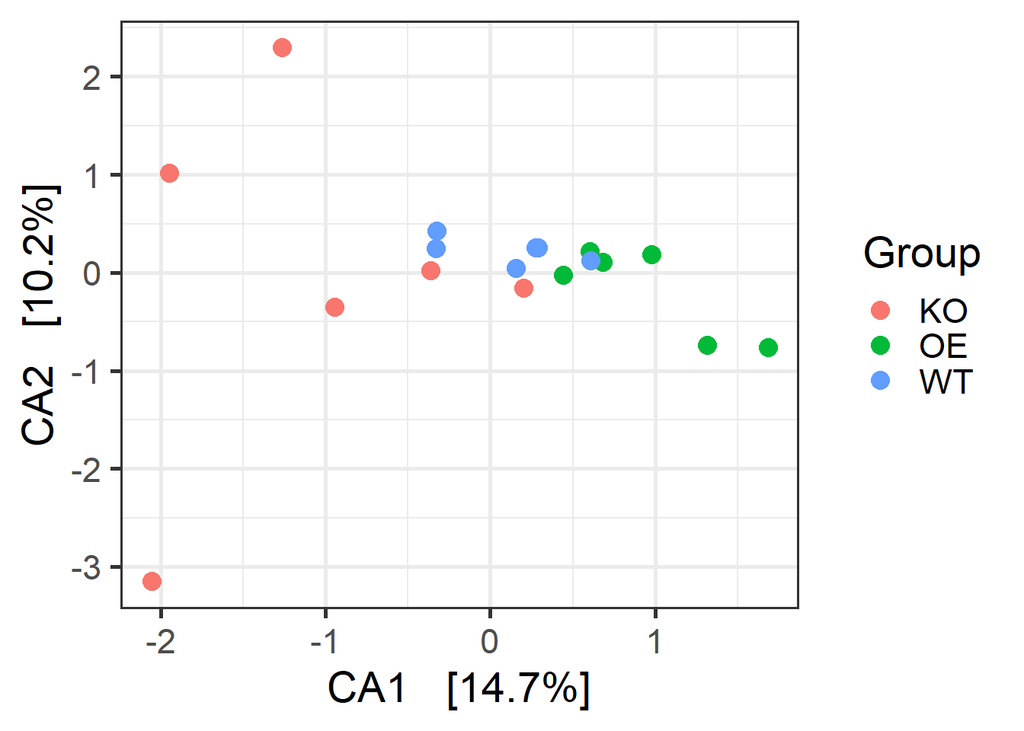

```r
pseq.cca <- ordinate(pseq, "CCA")
p <- plot_ordination(pseq, pseq.cca,
       type = "samples", color = "Group")
p <- p + geom_point(size = 4)
print(p)
```

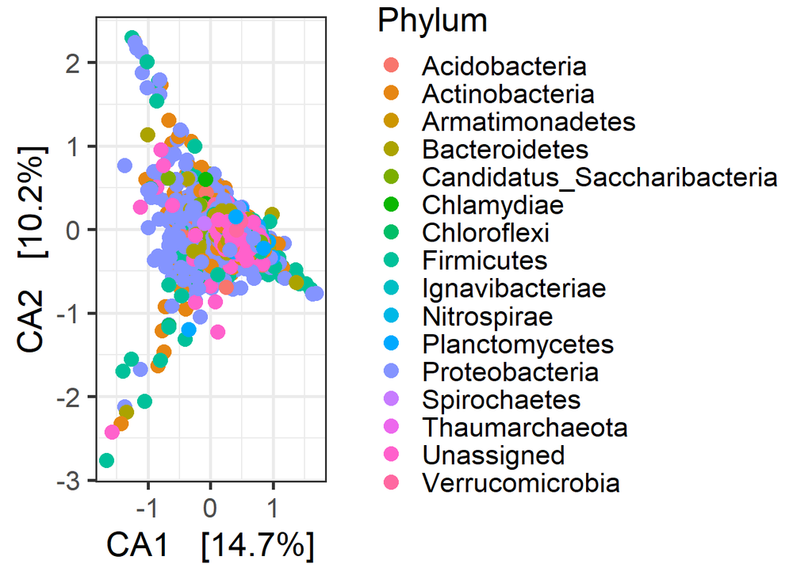

```r
# With taxa:
p <- plot_ordination(pseq, pseq.cca,
       type = "taxa", color = "Phylum")
p <- p + geom_point(size = 4)
print(p)
```

### 门水平微生物群落丰度展示

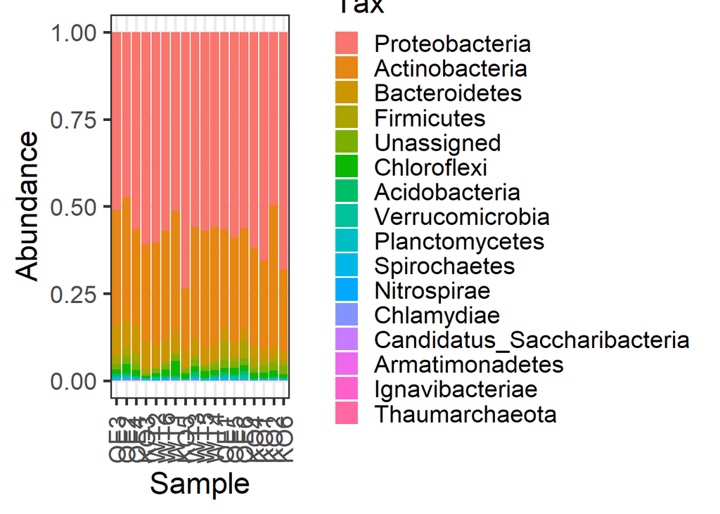

```r
ps1 <- ps %>%
  # subset_samples(Group == "OE") %>%
  tax_glom_wt(ranks = "Phylum") %>%
  microbiome::transform(transform = "compositional")

p <- ps1 %>%
  plot_composition(sample.sort = "Bacteroidetes", otu.sort = "abundance")
print(p)
```

### 微生物组成展示-核心微生物提取和可视化

提取相对丰度超过0.01的微生物，核心微生物提取和可视化：https://microbiome.github.io/tutorials/Core.html；

core函数用于提取核心微生物群落数据，detection代表提取相对丰度大于某个阈值的微生物。prevalence 代表出现额概率超过百分之多少的样本。

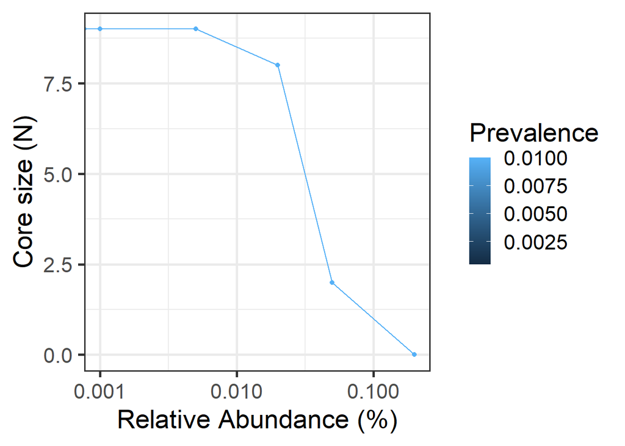

```r
ps_rela =  microbiome::transform(ps, "compositional")
pseq <- ps_rela %>%
  core(detection = 0.01, prevalence = 50/100)

# With compositional (relative) abundances
det <- c(0, 0.1, 0.5, 2, 5, 20)/100
prevalences <- seq(.05, 1, .05)
 #ggplot(d) + geom_point(aes(x, y)) + scale_x_continuous(trans="log10", limits=c(NA,1))


plot_core(pseq,prevalences = prevalences, detections = det, plot.type = "lineplot") + xlab("Relative Abundance (%)")
```

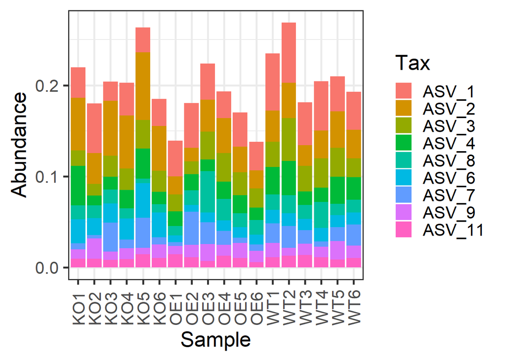

```r
p <- pseq %>%
  plot_composition(sample.sort = "Firmicutes", otu.sort = "abundance")

print(p)
```

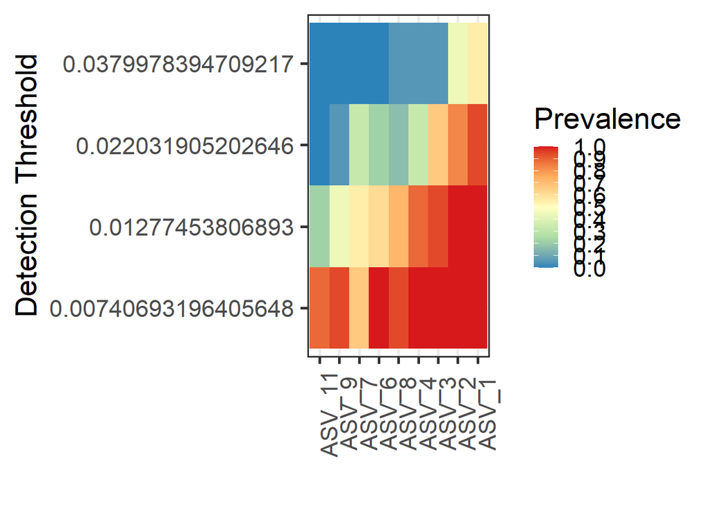

```r
library(RColorBrewer)
# library(reshape)
# BiocManager::install("reshape")
prevalences <- seq(.05, 1, .05)
detections <- 10^seq(log10(1e-3), log10(.2), length = 10)

# Also define gray color palette
gray <- gray(seq(0,1,length=5))
#pseq.rel<- microbiome::transform(pseq, 'compositional')
p <- plot_core(pseq, plot.type = "heatmap", colours = gray,
       prevalences = prevalences, detections = detections) +
    labs(x = "Detection Threshold (Relative Abundance (%))")

detections <- 10^seq(log10(1), log10(max(abundances(pseq))/10), length = 10)

p <- plot_core(pseq, plot.type = "heatmap",
             prevalences = prevalences,
             detections = detections,
         colours = rev(brewer.pal(5, "Spectral")),
         min.prevalence = .2, horizontal = TRUE)
print(p)
```

### 物种共有和特有情况分析可视化

物种存在与否做一个Ven图： https://microbiome.github.io/tutorials/core_venn.html

```r
library(eulerr)
library(microbiome)
# library(microbiomeutilities)
# # install.packages("devtools")
# devtools::install_github("microsud/microbiomeutilities")
pseq.rel <- microbiome::transform(ps, "compositional")
disease_states <- unique(as.character(meta(pseq.rel)$Group))
print(disease_states)
```

```
## [1] "KO" "OE" "WT"
```

```r
list_core <- c() # an empty object to store information

for (n in disease_states){ # for each variable n in DiseaseState
    #print(paste0("Identifying Core Taxa for ", n))

    ps.sub <- subset_samples(pseq.rel, Group == n) # Choose sample from DiseaseState by n

    core_m <- core_members(ps.sub, # ps.sub is phyloseq selected with only samples from g
                           detection = 0.001, # 0.001 in atleast 90% samples
                           prevalence = 0.75)
    print(paste0("No. of core taxa in ", n, " : ", length(core_m))) # print core taxa identified in each DiseaseState.
    list_core[[n]] <- core_m # add to a list core taxa for each group.
    #print(list_core)
}
```

```
## [1] "No. of core taxa in KO : 106"
## [1] "No. of core taxa in OE : 107"
## [1] "No. of core taxa in WT : 108"
```

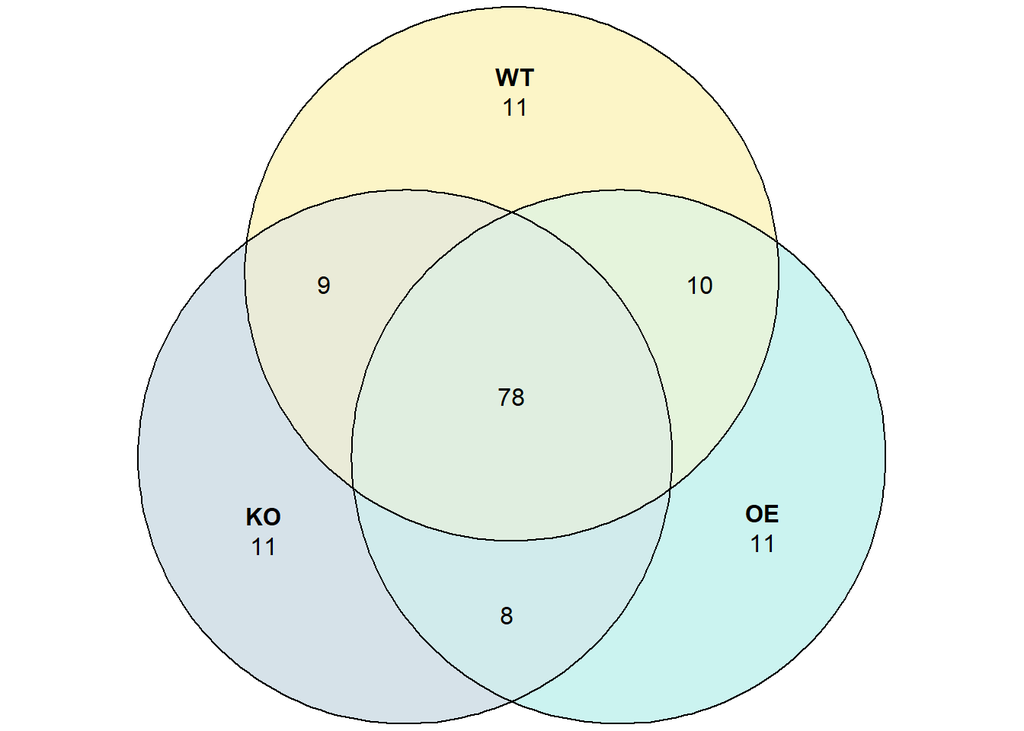

```r
mycols <- c(nonCRC="#d6e2e9", CRC="#cbf3f0", H="#fcf5c7")
plot(venn(list_core),
     fills = mycols)
```

### 微生物组样本分布分析

https://microbiome.github.io/tutorials/Landscaping.html

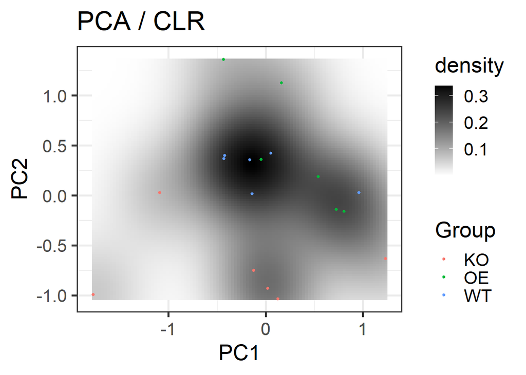

```r
# Convert to compositional data
pseq.rel <- microbiome::transform(ps, "compositional")

# Pick core taxa
pseq.core <- core(pseq.rel, detection = 1/1000, prevalence = 5/100)

p <- plot_landscape(pseq, method = "PCA", transformation = "clr", col = "Group") +
       labs(title = paste("PCA / CLR"))
print(p)
```

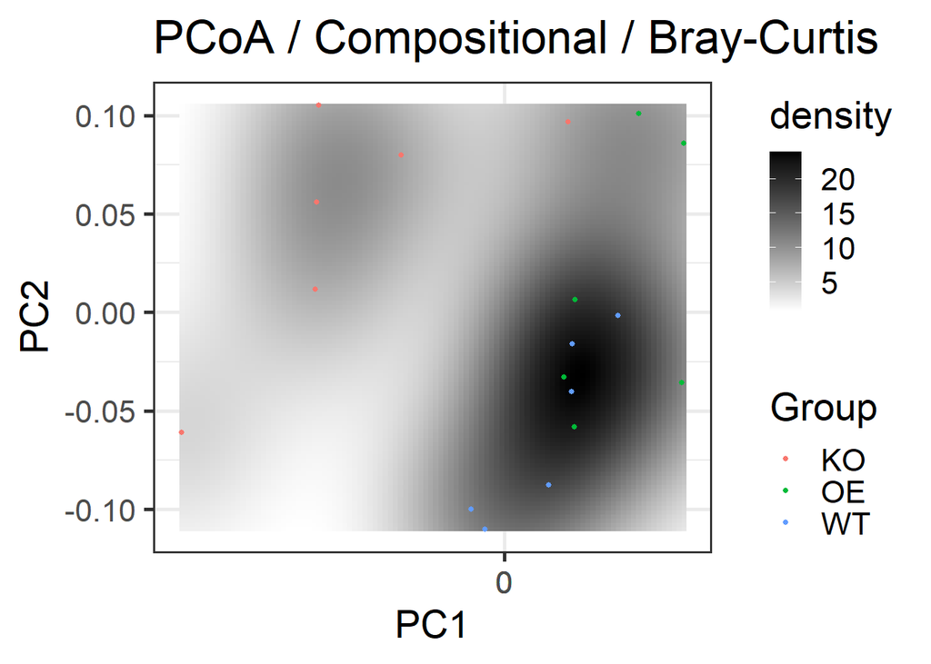

```r
p <- plot_landscape(microbiome::transform(pseq.core, "compositional"),
                      method = "PCoA", distance = "bray", col = "Group") +
       labs(title = paste("PCoA / Compositional / Bray-Curtis"))
print(p)
```

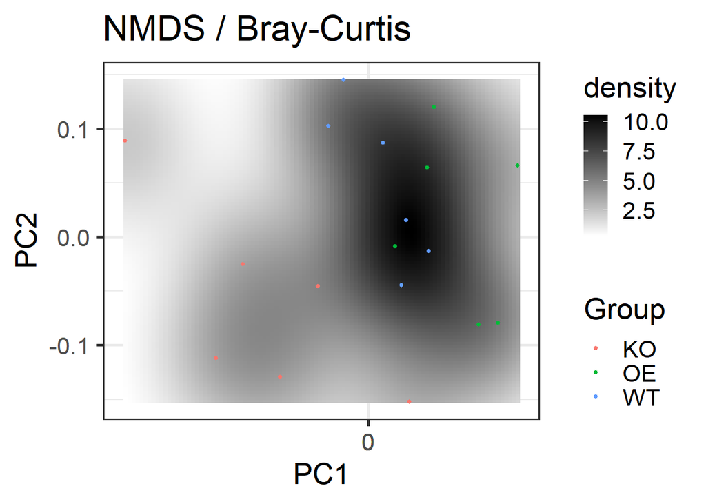

```r
p <- plot_landscape(pseq.core, "NMDS", "bray", col = "Group") +
       labs(title = paste("NMDS / Bray-Curtis"))
print(p)
```

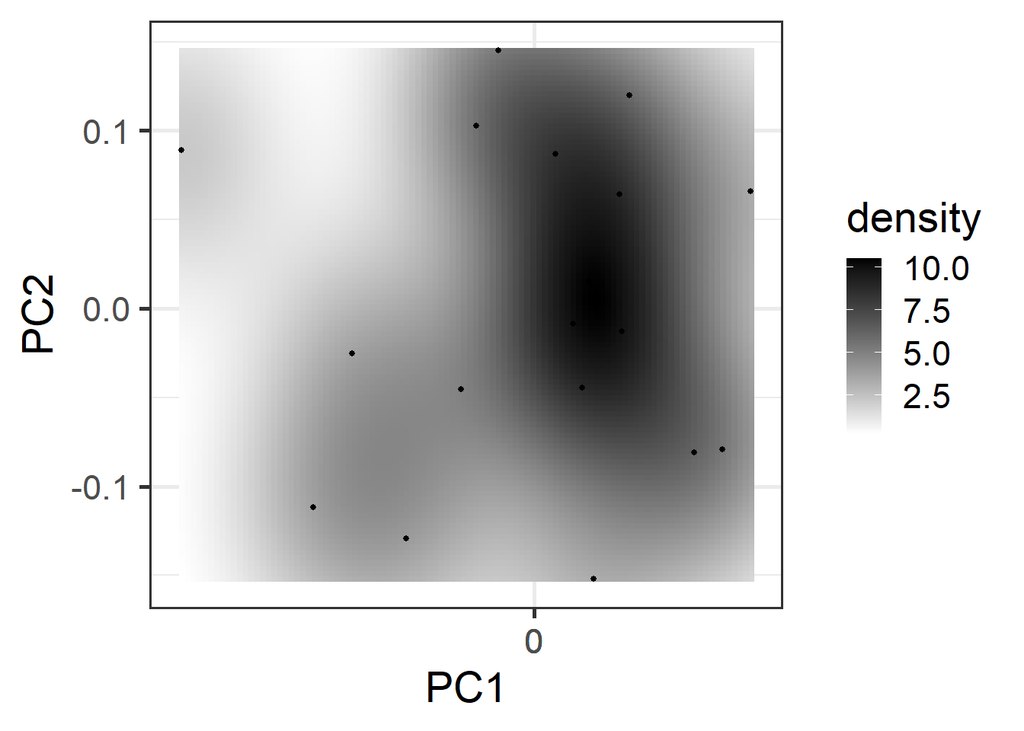

```r
set.seed(423542)
x <- pseq.core
quiet(x.ord <- ordinate(x, "NMDS", "bray"))
# Pick the projected data (first two columns + metadata)
proj <- phyloseq::plot_ordination(x, x.ord, justDF=TRUE)
# Rename the projection axes
names(proj)[1:2] <- paste("Comp", 1:2, sep=".")

# Same with a generic data.frame
# (note that random seed will affect the exact ordination)
p <- plot_landscape(proj[, 1:2], col = proj$nationality, legend = T)
print(p)
```

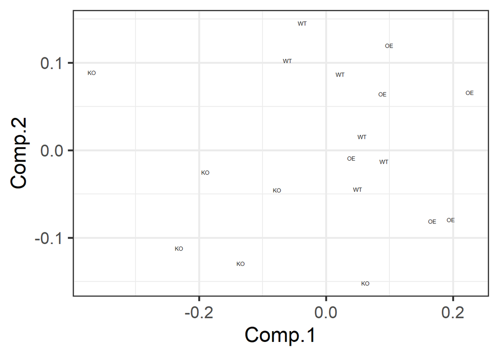

```r
# Visualize sample names:
ax1 <- names(proj)[[1]]
ax2 <- names(proj)[[2]]


p <- ggplot(aes_string(x = ax1, y = ax2, label = "Group"), data = proj) +
       geom_text(size = 2)
print(p)
```

### 使用热图展示微生物丰度信息

https://microbiome.github.io/tutorials/Heatmap.html

[figure not shown]

```r
library(reshape2)
# Pick data subset (DI samples from Phylum Bacteroidetes)
pseq2 <- ps %>%
         subset_taxa(Phylum == "Bacteroidetes")


# Z transformed abundance data
pseqz <- microbiome::transform(pseq2, "Z")

# Plot the abundances heatmap
dfm <- melt(abundances(pseqz))
colnames(dfm) <- c("Taxa", "Sample", "value")
heat(dfm, "Taxa", "Sample", "value")
```

[figure not shown]

```r
# Sort the matrix rows and cols directly
xo <- neat(abundances(pseqz), method = "NMDS", distance = "euclidean")

# Heatmap visualization
dfm <- melt(xo)
colnames(dfm) <- c("Taxa", "Sample", "value")
heat(dfm, "Taxa", "Sample", "value")
```

```r
sorted.rows <- neatsort(abundances(pseqz), "rows", method = "NMDS", distance = "euclidean")
```

### 指定微生物丰富展示和差异分析

https://microbiome.github.io/tutorials/post_hoc.html

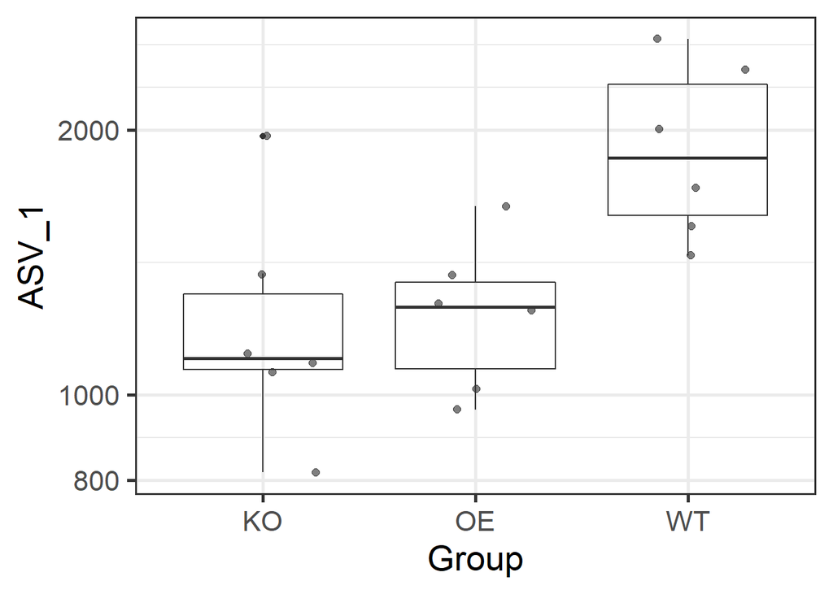

```r
p <- boxplot_abundance(ps, x = "Group", y = "ASV_1") + scale_y_log10()
print(p)
```

```r
library(tidyr)

# Analyse specific taxa
tax <- "ASV_1"

# Pick the signal (abundance) for this tax
sample_data(ps)$signal <- get_sample(ps, tax)


attach(meta(ps))
res<- pairwise.wilcox.test(signal, Group, p.adjust.method = 'BH')
resK<- kruskal.test(signal, Group)
print(resK)
```

```
##
##  Kruskal-Wallis rank sum test
##
## data:  signal and Group
## Kruskal-Wallis chi-squared = 8.4327, df = 2, p-value = 0.01475
```

### 使用DEsep2做差异分析

此为外界端口

https://microbiome.github.io/tutorials/deseq2.html

```r
library(magrittr)



# Only check the core taxa to speed up examples
pseq <- core(ps, detection = 50, prevalence = 80/100)

library(phyloseq)
library(reshape2)
library(DESeq2)
library(knitr)

# Running the DESeq2 analysis
ds2 <- phyloseq_to_deseq2(pseq, ~ Group)
dds <- DESeq(ds2)
res <- results(dds)
df <- as.data.frame(res)
df$taxon <- rownames(df)
df <- df %>% arrange(log2FoldChange, padj)


print(head(kable((df))))
```

```
## [1] "|        |   baseMean| log2FoldChange|     lfcSE|       stat|    pvalue|      padj|taxon   |"
## [2] "|:-------|----------:|--------------:|---------:|----------:|---------:|---------:|:-------|"
## [3] "|ASV_41  |  142.64608|     -1.1650662| 0.2489012| -4.6808383| 0.0000029| 0.0000486|ASV_41  |"
## [4] "|ASV_24  |  188.57611|     -1.0859586| 0.2946964| -3.6850076| 0.0002287| 0.0017279|ASV_24  |"
## [5] "|ASV_54  |  116.15914|     -1.0279530| 0.3758856| -2.7347499| 0.0062428| 0.0288902|ASV_54  |"
## [6] "|ASV_6   |  579.78849|     -0.9162078| 0.1609853| -5.6912532| 0.0000000| 0.0000009|ASV_6   |"
```

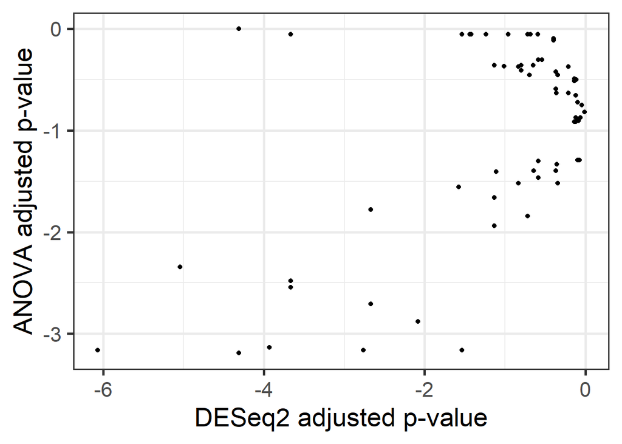

```r
# Identify top taxa based on standard ANOVA
source(system.file("extdata/check_anova.R", package = "microbiome"))
ano <- check_anova(pseq, "Group");
ano$log2FC <- log2(ano$ave.KO) - log2(ano$ave.OE)
taxa.anova <- as.character(subset(ano, padj < 0.01 & abs(log2FC) > log2(2))$taxa)

# lowPick the top taxa based on DESEq2
taxa.deseq <- subset(res, padj < 0.01 & abs(log2FoldChange) > log2(2))$taxon

# Check overlap
# Most DESEq2 taxa are confirmed with ANOVA


# Also the est p-values are well correlated (higher not so)
mf <- data.frame(df$padj, ano$padj)
p <- ggplot(mf, aes(x = log10(df$padj), y = log10(ano$padj))) +
  labs(x = 'DESeq2 adjusted p-value', y = 'ANOVA adjusted p-value') +
  geom_point()
print(p)
```

### limma 和t检验

外界端口

https://microbiome.github.io/tutorials/limma.html

```r
# Load libraries
library(microbiome)
library(ggplot2)
library(dplyr)


map = sample_data(ps)
map$ID = row.names(map)
sample_data(ps) = map

pssub =  subset_samples(ps,!Group %in% c("OE"));pssub
```

```
## phyloseq-class experiment-level object
## otu_table()   OTU Table:         [ 2861 taxa and 12 samples ]
## sample_data() Sample Data:       [ 12 samples by 12 sample variables ]
## tax_table()   Taxonomy Table:    [ 2861 taxa by 7 taxonomic ranks ]
## phy_tree()    Phylogenetic Tree: [ 2861 tips and 2860 internal nodes ]
```

```r
otu <- abundances(microbiome::transform(pssub, "log10"))
meta <- meta(pssub)

# Compare the two groups with limma
library(limma)

# Prepare the design matrix which states the groups for each sample
# in the otu
design <- cbind(intercept = 1, Grp2vs1 = meta[["Group"]])
rownames(design) <- rownames(meta)
design <- design[colnames(otu), ]

head(design)
```

```
##     intercept Grp2vs1
## KO1         1       1
## KO2         1       1
## KO3         1       1
## KO4         1       1
## KO5         1       1
## KO6         1       1
```

```r
# NOTE: results and p-values are given for all groupings in the design matrix
# Now focus on the second grouping ie. pairwise comparison
coef.index <- 2

# Fit the limma model
fit <- lmFit(otu, design)
fit <- eBayes(fit)

# Limma P-values
pvalues.limma = fit$p.value[, 2]

# Limma effect sizes
efs.limma <-  fit$coefficients[, "Grp2vs1"]

# Summarise
library(knitr)
kable(topTable(fit, coef = coef.index, p.value=0.1), digits = 2)
```

|  | logFC | AveExpr | t | P.Value | adj.P.Val | B |
| --- | --- | --- | --- | --- | --- | --- |
| ASV_1908 | 0.79 | 0.55 | 7.04 | 0 | 0.01 | 4.36 |
| ASV_1850 | 0.74 | 0.52 | 6.81 | 0 | 0.01 | 4.02 |
| ASV_204 | 0.68 | 1.31 | 5.76 | 0 | 0.02 | 2.39 |
| ASV_247 | 0.74 | 1.12 | 5.76 | 0 | 0.02 | 2.38 |
| ASV_1909 | 0.49 | 0.24 | 5.76 | 0 | 0.02 | 2.38 |
| ASV_112 | 0.60 | 1.50 | 5.59 | 0 | 0.03 | 2.10 |
| ASV_1191 | 0.56 | 0.28 | 5.40 | 0 | 0.03 | 1.78 |
| ASV_2583 | 0.55 | 0.32 | 5.34 | 0 | 0.03 | 1.67 |
| ASV_1910 | 0.59 | 0.43 | 5.26 | 0 | 0.03 | 1.53 |
| ASV_2076 | 0.59 | 0.34 | 5.25 | 0 | 0.03 | 1.53 |

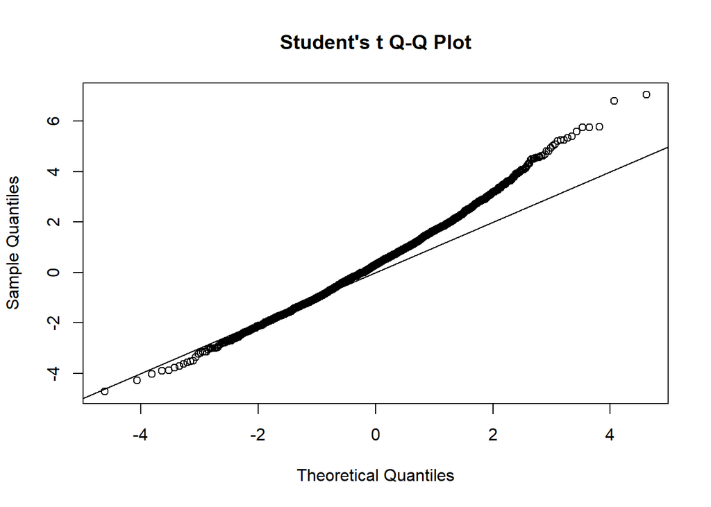

```r
# QQ
qqt(fit$t[, coef.index], df = fit$df.residual + fit$df.prior); abline(0,1)
```

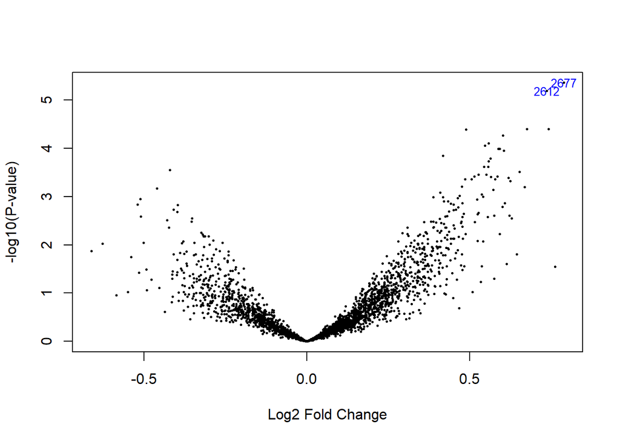

```r
# Volcano
volcanoplot(fit, coef = coef.index, highlight = coef.index)
```

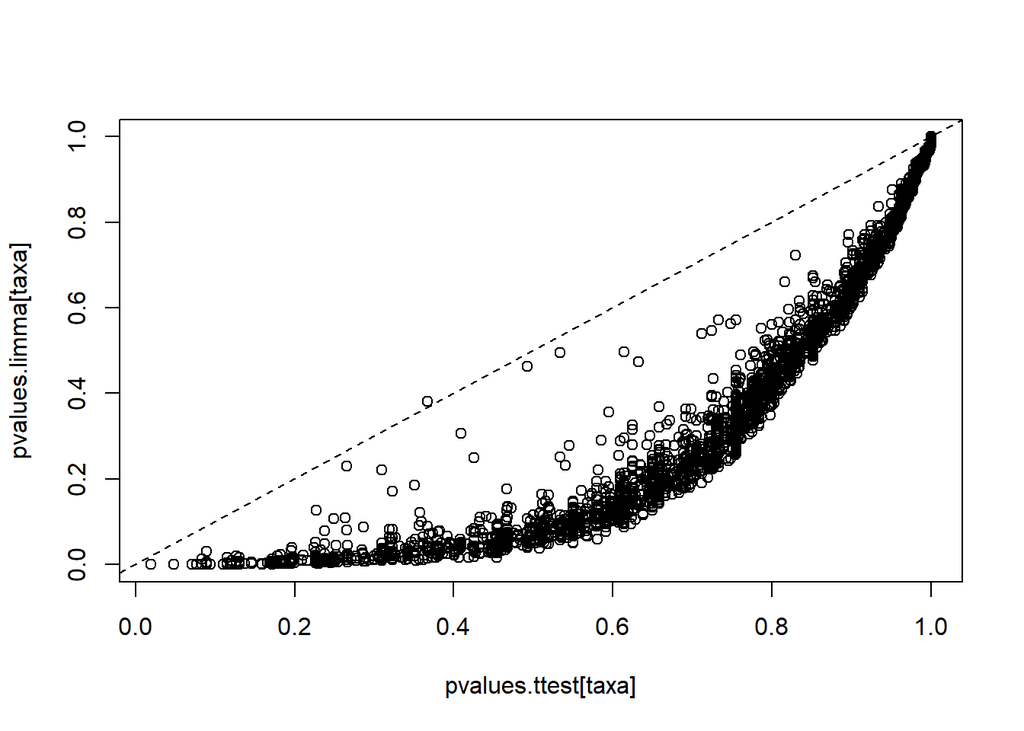

```r
# Compare the two groups with t-test
library(dplyr)
pvalues.ttest <- c()
male.samples <- dplyr::filter(meta, Group == "WT")$ID
female.samples <- dplyr::filter(meta, Group == "KO")$ID
for (tax in rownames(otu)) {
  pvalues.ttest[[tax]] <- t.test(otu[tax, male.samples], otu[tax, female.samples])$p.value
}
# Multiple testing correction
pvalues.ttest <- p.adjust(pvalues.ttest, method = "fdr")

# Compare p-values between limma and t-test
taxa <- rownames(otu)
plot(pvalues.ttest[taxa], pvalues.limma[taxa])
abline(0,1,lty = 2)
```

### 群落差异检测

外接端口

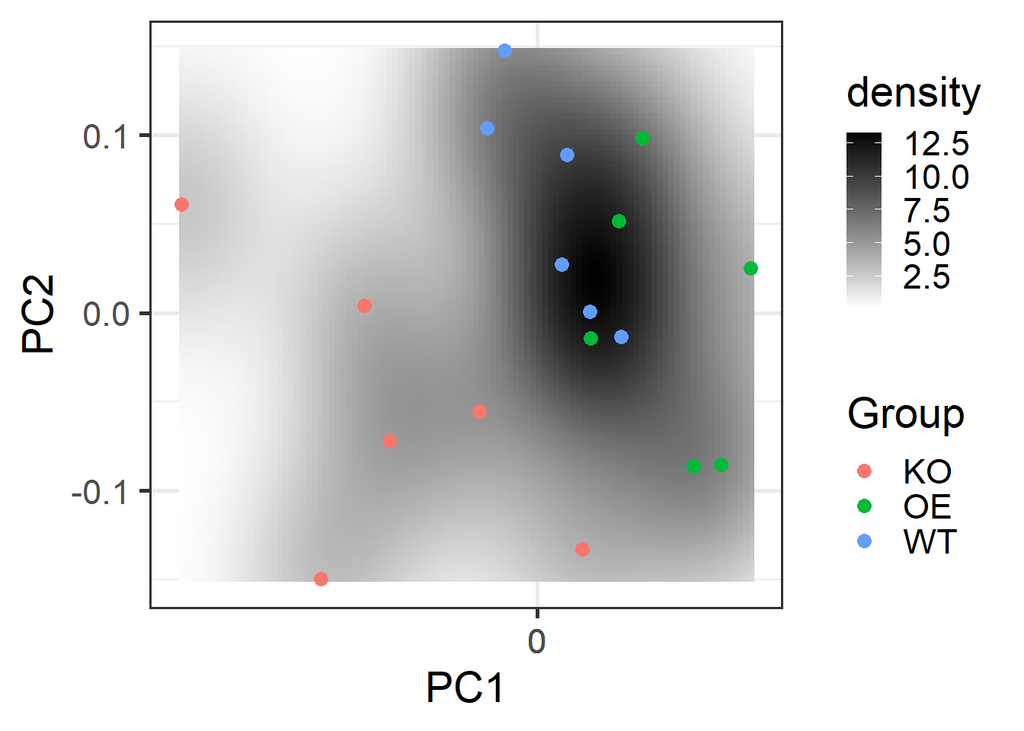

```r
# Pick relative abundances (compositional) and sample metadata
pseq.rel <- microbiome::transform(ps, "compositional")
otu <- abundances(pseq.rel)
meta <- meta(pseq.rel)

p <- plot_landscape(pseq.rel, method = "NMDS", distance = "bray", col = "Group", size = 3)
print(p)
```

```r
# samples x species as input
library(vegan)
permanova <- adonis(t(otu) ~ Group,
                    data = meta, permutations=99, method = "bray")

# P-value
print(as.data.frame(permanova$aov.tab)["Group", "Pr(>F)"])
```

```
## [1] 0.01
```